# Activación economía Montería-Córdoba

## Situación Problema

Este proyecto busca financiar iniciativas empresariales de diferentes sectores que sean desarrolladas por emprendedores que residan en la ciudad de Montería, departamento de Córdoba.

```r
setwd("~/GitHub/APGPAC/Data")
library(readr)
EMPRESAS_REGISTRADAS_MONTERIA_2005_2019_20241011 <- read_delim("EMPRESAS_REGISTRADAS_MONTERIA_2005-2019_20241011_V2.csv",
                                                               delim = ";", escape_double = FALSE, trim_ws = TRUE)
Empresas=EMPRESAS_REGISTRADAS_MONTERIA_2005_2019_20241011


library(dplyr)#este paquete sirve para filtar
Monteria=Empresas %>%
          filter(`MUN-NOTIFICACION`=="23001 - MONTERIA")

library(agricolae)#para hacer tablas de frecuencias v cuantitativas
library(fdth)  #para hacer tablas de frecuencias cualitativas
tabla1=fdt_cat(Monteria$`CIIU-1`);tabla1
```

```
##  Category    f   rf rf(%)    cf  cf(%)
##       N/A 3035 0.10 10.17  3035  10.17
##     G4711 1992 0.07  6.68  5027  16.85
##     S9499 1495 0.05  5.01  6522  21.86
##     I5611 1056 0.04  3.54  7578  25.40
##     I5630 1042 0.03  3.49  8620  28.89
##     G4773  736 0.02  2.47  9356  31.36
##     G4771  711 0.02  2.38 10067  33.74
##     R9200  667 0.02  2.24 10734  35.98
##     F4111  532 0.02  1.78 11266  37.76
##     G4719  528 0.02  1.77 11794  39.53
##     S9602  522 0.02  1.75 12316  41.28
##     F4290  435 0.01  1.46 12751  42.74
##     G4520  425 0.01  1.42 13176  44.17
##     I5619  408 0.01  1.37 13584  45.53
##     G4752  388 0.01  1.30 13972  46.83
##     G4761  377 0.01  1.26 14349  48.10
##     G4723  372 0.01  1.25 14721  49.34
##     N8299  346 0.01  1.16 15067  50.50
##     G4754  342 0.01  1.15 15409  51.65
##     M7110  336 0.01  1.13 15745  52.78
##     M7020  335 0.01  1.12 16080  53.90
##     G4741  327 0.01  1.10 16407  55.00
##     K6621  320 0.01  1.07 16727  56.07
##     Q8621  299 0.01  1.00 17026  57.07
##     G4759  286 0.01  0.96 17312  58.03
##     J6110  271 0.01  0.91 17583  58.94
##     L6810  270 0.01  0.91 17853  59.84
##     M7310  268 0.01  0.90 18121  60.74
##     G4541  263 0.01  0.88 18384  61.62
##     C1410  237 0.01  0.79 18621  62.42
##     G4530  234 0.01  0.78 18855  63.20
##     G4729  212 0.01  0.71 19067  63.91
##     M6910  212 0.01  0.71 19279  64.62
##     F4330  211 0.01  0.71 19490  65.33
##     H5221  208 0.01  0.70 19698  66.03
##     G4799  199 0.01  0.67 19897  66.69
##     H4923  195 0.01  0.65 20092  67.35
##     C1081  191 0.01  0.64 20283  67.99
##     G4772  191 0.01  0.64 20474  68.63
```

[output cut: 342 more lines]

```
##     H5022    1 0.00  0.00 29819  99.95
##     H5111    1 0.00  0.00 29820  99.96
##     H5121    1 0.00  0.00 29821  99.96
##     H5223    1 0.00  0.00 29822  99.96
##     I5520    1 0.00  0.00 29823  99.97
##     J5819    1 0.00  0.00 29824  99.97
##     J5913    1 0.00  0.00 29825  99.97
##     K6491    1 0.00  0.00 29826  99.98
##     K6522    1 0.00  0.00 29827  99.98
##     K6532    1 0.00  0.00 29828  99.98
##     K6614    1 0.00  0.00 29829  99.99
##     K6615    1 0.00  0.00 29830  99.99
##     N8292    1 0.00  0.00 29831  99.99
##     O8412    1 0.00  0.00 29832 100.00
##     T9700    1 0.00  0.00 29833 100.00
```

```r
#tabla de frecuencias
table(Monteria$`CIIU-1`)
```

[output not shown]

[output cut: 8 more lines]

```
##   335   336    15    15    14   268     3    33    23    80    46  3035    14
## N7721 N7722 N7729 N7730 N7810 N7820 N7830 N7911 N7912 N7990 N8010 N8020 N8030
##     7     4    38    71     3    21    34    53    10     7    26    24     2
## N8110 N8121 N8129 N8130 N8211 N8219 N8220 N8230 N8291 N8292 N8299 O8412 O8413
##     4    12    33     9     8   106    12    62    13     1   346     1    27
## O8430 P8511 P8512 P8513 P8521 P8522 P8523 P8530 P8541 P8543 P8544 P8551 P8552
##     3    20    48     4     2     5    11     8     3     8     6    27    17
## P8553 P8559 P8560 Q8610 Q8621 Q8622 Q8691 Q8692 Q8699 Q8710 Q8720 Q8730 Q8790
##     9    37    33    73   299   113    89    46   140     4     2     2     3
## Q8810 Q8890 R9001 R9002 R9004 R9005 R9006 R9007 R9008 R9101 R9200 R9311 R9312
##     2    13     3     8     6     4    12    27    10     4   667    81     3
## R9319 R9321 R9329 S9411 S9412 S9491 S9499 S9511 S9512 S9521 S9522 S9523 S9524
##    23     5   189     4     3     2  1495    54    33    10    39     6     4
## S9529 S9601 S9602 S9603 S9609 T9700
##    60    21   522    33    83     1
```

```r
MonteriaActividades <- data.frame(table(Monteria$Actividad))
MonteriaActividadesDesc <- MonteriaActividades %>%
  arrange(desc(Freq))
MonteriaActividadesPrincipales <- head(MonteriaActividadesDesc, 10)


#diagrama barras

setwd("~/GitHub/APGPAC/Data")
library(readr)
EMPRESAS_REGISTRADAS_MONTERIA_2005_2019_20241011 <- read_delim("EMPRESAS_REGISTRADAS_MONTERIA_2005-2019_20241011_V2.csv",
                                                               delim = ";", escape_double = FALSE, trim_ws = TRUE)
Empresas=EMPRESAS_REGISTRADAS_MONTERIA_2005_2019_20241011


library(dplyr)#este paquete sirve para filtar

Monteria=Empresas %>%
          filter(`MUN-NOTIFICACION`=="23001 - MONTERIA")

library(agricolae)#para hacer tablas de frecuencias v cuantitativas
library(fdth)  #para hacer tablas de frecuencias cualitativas
tabla1=fdt_cat(Monteria$`CIIU-1`);tabla1
```

```
##  Category    f   rf rf(%)    cf  cf(%)
##       N/A 3035 0.10 10.17  3035  10.17
##     G4711 1992 0.07  6.68  5027  16.85
##     S9499 1495 0.05  5.01  6522  21.86
##     I5611 1056 0.04  3.54  7578  25.40
##     I5630 1042 0.03  3.49  8620  28.89
##     G4773  736 0.02  2.47  9356  31.36
##     G4771  711 0.02  2.38 10067  33.74
##     R9200  667 0.02  2.24 10734  35.98
##     F4111  532 0.02  1.78 11266  37.76
##     G4719  528 0.02  1.77 11794  39.53
##     S9602  522 0.02  1.75 12316  41.28
##     F4290  435 0.01  1.46 12751  42.74
##     G4520  425 0.01  1.42 13176  44.17
##     I5619  408 0.01  1.37 13584  45.53
##     G4752  388 0.01  1.30 13972  46.83
##     G4761  377 0.01  1.26 14349  48.10
##     G4723  372 0.01  1.25 14721  49.34
##     N8299  346 0.01  1.16 15067  50.50
##     G4754  342 0.01  1.15 15409  51.65
##     M7110  336 0.01  1.13 15745  52.78
##     M7020  335 0.01  1.12 16080  53.90
##     G4741  327 0.01  1.10 16407  55.00
##     K6621  320 0.01  1.07 16727  56.07
##     Q8621  299 0.01  1.00 17026  57.07
##     G4759  286 0.01  0.96 17312  58.03
##     J6110  271 0.01  0.91 17583  58.94
##     L6810  270 0.01  0.91 17853  59.84
##     M7310  268 0.01  0.90 18121  60.74
##     G4541  263 0.01  0.88 18384  61.62
##     C1410  237 0.01  0.79 18621  62.42
##     G4530  234 0.01  0.78 18855  63.20
##     G4729  212 0.01  0.71 19067  63.91
##     M6910  212 0.01  0.71 19279  64.62
##     F4330  211 0.01  0.71 19490  65.33
##     H5221  208 0.01  0.70 19698  66.03
##     G4799  199 0.01  0.67 19897  66.69
##     H4923  195 0.01  0.65 20092  67.35
##     C1081  191 0.01  0.64 20283  67.99
##     G4772  191 0.01  0.64 20474  68.63
```

[output cut: 342 more lines]

```
##     H5022    1 0.00  0.00 29819  99.95
##     H5111    1 0.00  0.00 29820  99.96
##     H5121    1 0.00  0.00 29821  99.96
##     H5223    1 0.00  0.00 29822  99.96
##     I5520    1 0.00  0.00 29823  99.97
##     J5819    1 0.00  0.00 29824  99.97
##     J5913    1 0.00  0.00 29825  99.97
##     K6491    1 0.00  0.00 29826  99.98
##     K6522    1 0.00  0.00 29827  99.98
##     K6532    1 0.00  0.00 29828  99.98
##     K6614    1 0.00  0.00 29829  99.99
##     K6615    1 0.00  0.00 29830  99.99
##     N8292    1 0.00  0.00 29831  99.99
##     O8412    1 0.00  0.00 29832 100.00
##     T9700    1 0.00  0.00 29833 100.00
```

```r
#tabla de frecuencias
table(Monteria$`CIIU-1`)
```

[output not shown]

[output cut: 8 more lines]

```
##   335   336    15    15    14   268     3    33    23    80    46  3035    14
## N7721 N7722 N7729 N7730 N7810 N7820 N7830 N7911 N7912 N7990 N8010 N8020 N8030
##     7     4    38    71     3    21    34    53    10     7    26    24     2
## N8110 N8121 N8129 N8130 N8211 N8219 N8220 N8230 N8291 N8292 N8299 O8412 O8413
##     4    12    33     9     8   106    12    62    13     1   346     1    27
## O8430 P8511 P8512 P8513 P8521 P8522 P8523 P8530 P8541 P8543 P8544 P8551 P8552
##     3    20    48     4     2     5    11     8     3     8     6    27    17
## P8553 P8559 P8560 Q8610 Q8621 Q8622 Q8691 Q8692 Q8699 Q8710 Q8720 Q8730 Q8790
##     9    37    33    73   299   113    89    46   140     4     2     2     3
## Q8810 Q8890 R9001 R9002 R9004 R9005 R9006 R9007 R9008 R9101 R9200 R9311 R9312
##     2    13     3     8     6     4    12    27    10     4   667    81     3
## R9319 R9321 R9329 S9411 S9412 S9491 S9499 S9511 S9512 S9521 S9522 S9523 S9524
##    23     5   189     4     3     2  1495    54    33    10    39     6     4
## S9529 S9601 S9602 S9603 S9609 T9700
##    60    21   522    33    83     1
```

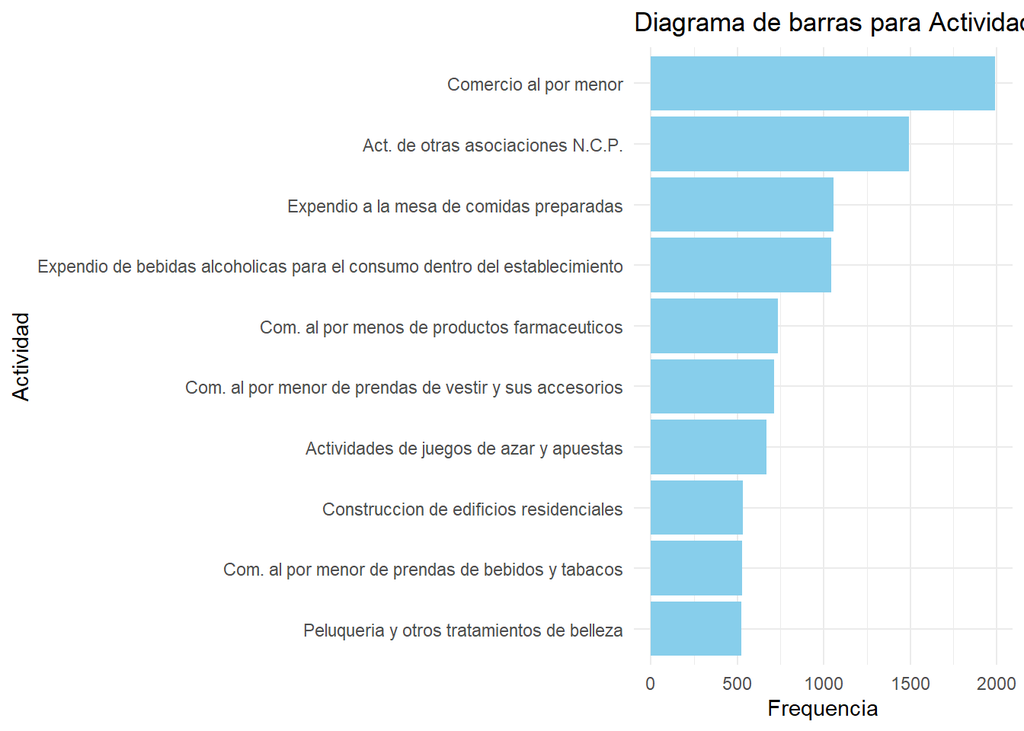

```r
MonteriaActividades <- data.frame(table(Monteria$Actividad))
MonteriaActividadesDesc <- MonteriaActividades %>%
  arrange(desc(Freq))
MonteriaActividadesPrincipales <- head(MonteriaActividadesDesc, 10)


#diagrama barras

library(ggplot2)
# Assuming your data frame is named "MonteriasActividades" with variables "Var1" and "Freq"
ggplot(MonteriaActividadesPrincipales,
       aes(x = reorder(Var1, Freq, FUN = "mean"), y = Freq)) +
  geom_bar(stat = "identity", fill = "skyblue") +
  coord_flip() +
  labs(title = "Diagrama de barras para Actividad Monteria",#titulo
       x = "Actividad",#titulo eje x
       y = "Frequencia" #titulo eje y
       ) +
  theme_minimal()
```

## Agencia Financiadora del Proyecto

La agencia financiadora de este proyecto es el FONDO EMPRENDER. Su objetivo general es incentivar y facilitar la generación y creación de empresas, contribuyendo al desarrollo humano y la inserción de estas en el sector productivo. De esta manera, se busca coadyuvar al desarrollo social y económico del país a través de una formación pertinente y la provisión de capital semilla.

## Datos relevantes del Proyecto

### Monto financiado

Para la presente convocatoria, el Fondo Emprender entregará recursos de hasta SETENTA MILLONES DE PESOS M/CTE ($70.000.000,00). Lo anterior, si el plan de negocio genera hasta tres (3) o más empleos formales y directos.

### Sectores económicos de la convocatoria

Multisectorial.

### Fechas importantes

Apertura: 18 de septiembre de 2024 Cierre: 18 de noviembre de 2024

### Requisitos para aplicar

1. Ser colombiano.
2. Ser mayor de edad y contar con plenas facultades legales para suscribir contratos.
3. No encontrarse sujeto a un conflicto de intereses, inhabilidades e incompatibilidades, de acuerdo con lo indicado en la Constitución Nacional.
4. No tener nexos de parentesco hasta el cuarto grado de consanguinidad, segundo de afinidad, y primero civil con funcionarios o contratistas del SENA en el nivel directivo del orden nacional o del orden regional en donde se presenta el plan de negocio. Esta restricción aplica a los funcionarios o contratistas de los Centros de Desarrollo Empresarial y Unidades Externas de Emprendimiento vinculadas al programa de Fondo Emprender, así como evaluadores, operadores y demás personas que tengan injerencia en el proceso.
5. No habérsele asignado anteriormente recursos del Fondo Emprender por parte del Consejo Directivo Nacional del SENA – CDN.
6. No estar incurso en ninguna causal de inhabilidad o incompatibilidad consagradas en la ley para contratar con el Estado.
7. No estar desempeñando ningún cargo público.
8. No contar con ningún tipo de vinculación laboral o contractual con el Servicio Nacional de Aprendizaje - SENA, exceptuando el contrato de aprendizaje.
9. La dedicación de los beneficiarios al proyecto deberá ser de tiempo completo y exclusivo, salvo que, se justifique la dedicación parcial, indicando su compromiso de asistir directa y personalmente a todas las citaciones que realicen el SENA, el operador de los recursos o la interventoría.